# PRA2-Tipologia i cicle de vida de les dades - HousePrices

Damián & Eusebi

26/5/2020

S’assignen a variables el dataset de train i el de test

```r
#summary(cars)
train <- read_csv('HousePrices/train.csv' )
test <- read_csv("HousePrices/test.csv")
```

# Exploració del dataset

```r
names(train)
```

```
##  [1] "Id"            "MSSubClass"    "MSZoning"      "LotFrontage"
##  [5] "LotArea"       "Street"        "Alley"         "LotShape"
##  [9] "LandContour"   "Utilities"     "LotConfig"     "LandSlope"
## [13] "Neighborhood"  "Condition1"    "Condition2"    "BldgType"
## [17] "HouseStyle"    "OverallQual"   "OverallCond"   "YearBuilt"
## [21] "YearRemodAdd"  "RoofStyle"     "RoofMatl"      "Exterior1st"
## [25] "Exterior2nd"   "MasVnrType"    "MasVnrArea"    "ExterQual"
## [29] "ExterCond"     "Foundation"    "BsmtQual"      "BsmtCond"
## [33] "BsmtExposure"  "BsmtFinType1"  "BsmtFinSF1"    "BsmtFinType2"
## [37] "BsmtFinSF2"    "BsmtUnfSF"     "TotalBsmtSF"   "Heating"
## [41] "HeatingQC"     "CentralAir"    "Electrical"    "1stFlrSF"
## [45] "2ndFlrSF"      "LowQualFinSF"  "GrLivArea"     "BsmtFullBath"
## [49] "BsmtHalfBath"  "FullBath"      "HalfBath"      "BedroomAbvGr"
## [53] "KitchenAbvGr"  "KitchenQual"   "TotRmsAbvGrd"  "Functional"
## [57] "Fireplaces"    "FireplaceQu"   "GarageType"    "GarageYrBlt"
## [61] "GarageFinish"  "GarageCars"    "GarageArea"    "GarageQual"
## [65] "GarageCond"    "PavedDrive"    "WoodDeckSF"    "OpenPorchSF"
## [69] "EnclosedPorch" "3SsnPorch"     "ScreenPorch"   "PoolArea"
## [73] "PoolQC"        "Fence"         "MiscFeature"   "MiscVal"
## [77] "MoSold"        "YrSold"        "SaleType"      "SaleCondition"
## [81] "SalePrice"
```

```r
summary(train)
```

```
##        Id           MSSubClass      MSZoning          LotFrontage
##  Min.   :   1.0   Min.   : 20.0   Length:1460        Min.   : 21.00
##  1st Qu.: 365.8   1st Qu.: 20.0   Class :character   1st Qu.: 59.00
##  Median : 730.5   Median : 50.0   Mode  :character   Median : 69.00
##  Mean   : 730.5   Mean   : 56.9                      Mean   : 70.05
##  3rd Qu.:1095.2   3rd Qu.: 70.0                      3rd Qu.: 80.00
##  Max.   :1460.0   Max.   :190.0                      Max.   :313.00
##                                                      NA's   :259
##     LotArea          Street             Alley             LotShape
##  Min.   :  1300   Length:1460        Length:1460        Length:1460
##  1st Qu.:  7554   Class :character   Class :character   Class :character
##  Median :  9478   Mode  :character   Mode  :character   Mode  :character
##  Mean   : 10517
##  3rd Qu.: 11602
##  Max.   :215245
##
##  LandContour         Utilities          LotConfig
##  Length:1460        Length:1460        Length:1460
##  Class :character   Class :character   Class :character
##  Mode  :character   Mode  :character   Mode  :character
##
##
##
##
##   LandSlope         Neighborhood        Condition1
##  Length:1460        Length:1460        Length:1460
##  Class :character   Class :character   Class :character
##  Mode  :character   Mode  :character   Mode  :character
##
##
##
##
##   Condition2          BldgType          HouseStyle         OverallQual
##  Length:1460        Length:1460        Length:1460        Min.   : 1.000
##  Class :character   Class :character   Class :character   1st Qu.: 5.000
##  Mode  :character   Mode  :character   Mode  :character   Median : 6.000
##                                                           Mean   : 6.099
##                                                           3rd Qu.: 7.000
##                                                           Max.   :10.000
##
```

[output cut: 121 more lines]

```
##  Min.   :    0.00   Min.   : 1.000   Min.   :2006   Length:1460
##  1st Qu.:    0.00   1st Qu.: 5.000   1st Qu.:2007   Class :character
##  Median :    0.00   Median : 6.000   Median :2008   Mode  :character
##  Mean   :   43.49   Mean   : 6.322   Mean   :2008
##  3rd Qu.:    0.00   3rd Qu.: 8.000   3rd Qu.:2009
##  Max.   :15500.00   Max.   :12.000   Max.   :2010
##
##  SaleCondition        SalePrice
##  Length:1460        Min.   : 34900
##  Class :character   1st Qu.:129975
##  Mode  :character   Median :163000
##                     Mean   :180921
##                     3rd Qu.:214000
##                     Max.   :755000
##
```

```r
str(train)
```

```
## Classes 'spec_tbl_df', 'tbl_df', 'tbl' and 'data.frame': 1460 obs. of  81 variables:
##  $ Id           : num  1 2 3 4 5 6 7 8 9 10 ...
##  $ MSSubClass   : num  60 20 60 70 60 50 20 60 50 190 ...
##  $ MSZoning     : chr  "RL" "RL" "RL" "RL" ...
##  $ LotFrontage  : num  65 80 68 60 84 85 75 NA 51 50 ...
##  $ LotArea      : num  8450 9600 11250 9550 14260 ...
##  $ Street       : chr  "Pave" "Pave" "Pave" "Pave" ...
##  $ Alley        : chr  NA NA NA NA ...
##  $ LotShape     : chr  "Reg" "Reg" "IR1" "IR1" ...
##  $ LandContour  : chr  "Lvl" "Lvl" "Lvl" "Lvl" ...
##  $ Utilities    : chr  "AllPub" "AllPub" "AllPub" "AllPub" ...
##  $ LotConfig    : chr  "Inside" "FR2" "Inside" "Corner" ...
##  $ LandSlope    : chr  "Gtl" "Gtl" "Gtl" "Gtl" ...
##  $ Neighborhood : chr  "CollgCr" "Veenker" "CollgCr" "Crawfor" ...
##  $ Condition1   : chr  "Norm" "Feedr" "Norm" "Norm" ...
##  $ Condition2   : chr  "Norm" "Norm" "Norm" "Norm" ...
##  $ BldgType     : chr  "1Fam" "1Fam" "1Fam" "1Fam" ...
##  $ HouseStyle   : chr  "2Story" "1Story" "2Story" "2Story" ...
##  $ OverallQual  : num  7 6 7 7 8 5 8 7 7 5 ...
##  $ OverallCond  : num  5 8 5 5 5 5 5 6 5 6 ...
##  $ YearBuilt    : num  2003 1976 2001 1915 2000 ...
##  $ YearRemodAdd : num  2003 1976 2002 1970 2000 ...
##  $ RoofStyle    : chr  "Gable" "Gable" "Gable" "Gable" ...
##  $ RoofMatl     : chr  "CompShg" "CompShg" "CompShg" "CompShg" ...
##  $ Exterior1st  : chr  "VinylSd" "MetalSd" "VinylSd" "Wd Sdng" ...
##  $ Exterior2nd  : chr  "VinylSd" "MetalSd" "VinylSd" "Wd Shng" ...
##  $ MasVnrType   : chr  "BrkFace" "None" "BrkFace" "None" ...
##  $ MasVnrArea   : num  196 0 162 0 350 0 186 240 0 0 ...
##  $ ExterQual    : chr  "Gd" "TA" "Gd" "TA" ...
##  $ ExterCond    : chr  "TA" "TA" "TA" "TA" ...
##  $ Foundation   : chr  "PConc" "CBlock" "PConc" "BrkTil" ...
##  $ BsmtQual     : chr  "Gd" "Gd" "Gd" "TA" ...
##  $ BsmtCond     : chr  "TA" "TA" "TA" "Gd" ...
##  $ BsmtExposure : chr  "No" "Gd" "Mn" "No" ...
##  $ BsmtFinType1 : chr  "GLQ" "ALQ" "GLQ" "ALQ" ...
##  $ BsmtFinSF1   : num  706 978 486 216 655 ...
##  $ BsmtFinType2 : chr  "Unf" "Unf" "Unf" "Unf" ...
##  $ BsmtFinSF2   : num  0 0 0 0 0 0 0 32 0 0 ...
##  $ BsmtUnfSF    : num  150 284 434 540 490 64 317 216 952 140 ...
##  $ TotalBsmtSF  : num  856 1262 920 756 1145 ...
```

[output cut: 111 more lines]

```
##   ..   OpenPorchSF = col_double(),
##   ..   EnclosedPorch = col_double(),
##   ..   `3SsnPorch` = col_double(),
##   ..   ScreenPorch = col_double(),
##   ..   PoolArea = col_double(),
##   ..   PoolQC = col_character(),
##   ..   Fence = col_character(),
##   ..   MiscFeature = col_character(),
##   ..   MiscVal = col_double(),
##   ..   MoSold = col_double(),
##   ..   YrSold = col_double(),
##   ..   SaleType = col_character(),
##   ..   SaleCondition = col_character(),
##   ..   SalePrice = col_double()
##   .. )
```

# DESCRIPCIó i OBJECTIU

Aquest dataset conté les característiques d’un conjunt de cases amb 79 variables que descriuen gairebé completament cada aspecte d’aquestes cases residencials ubicades en Ames, Iowa. Aquest data set forma part d’un challenge en Kaggle anomenat: “HousePrices: Advance Regression Techniques” on el repte és predir el preu final de cada casa.

En el dataset Hi ha 1460 obs.amb 81 atributs, on la variable a predir és contínua (SalePrice). Addicionalment a la predicció dels preus, es fa un anàlisi per barris i una comparació dels preus de venda entre els anys 80 i els 90.

# Anàlisi

S’identifiquen inicialment els atributs numèrics que poden ser d’interès per l’estimació del preu de la casa. Identificació atributs numèrics:

OverallQual: Rates the overall material and finish of the house

```
   10   Very Excellent
   9    Excellent
   8    Very Good
   7    Good
   6    Above Average
   5    Average
   4    Below Average
   3    Fair
   2    Poor
   1    Very Poor
```

OverallCond: Rates the overall condition of the house

```
   10   Very Excellent
   9    Excellent
   8    Very Good
   7    Good
   6    Above Average
   5    Average
   4    Below Average
   3    Fair
   2    Poor
   1    Very Poor
```

YearBuilt: Original construction date YearRemodAdd: Remodel date (same as construction date if no remodeling or additions) MasVnrArea: Masonry veneer area in square feet BsmtFinSF1: Type 1 finished square feet BsmtFinSF2: Type 2 finished square feet BsmtUnfSF: Unfinished square feet of basement area # –BsmtUnfSF: Unfinished square feet of basement area TotalBsmtSF: Total square feet of basement area 1stFlrSF: First Floor square feet 2ndFlrSF: Second floor square feet LowQualFinSF: Low quality finished square feet (all floors) GrLivArea: Above grade (ground) living area square feet BsmtFullBath: Basement full bathrooms #– BsmtHalfBath: Basement half bathrooms FullBath: Full bathrooms above grade # –HalfBath: Half baths above grade TotRmsAbvGrd: Total rooms above grade (does not include bathrooms) Bedroom: Bedrooms above grade (does NOT include basement bedrooms) Kitchen: Kitchens above grade Fireplaces: Number of fireplaces GarageYrBlt: Year garage was built GarageCars: Size of garage in car capacity GarageArea: Size of garage in square feet WoodDeckSF: Wood deck area in square feet OpenPorchSF: Open porch area in square feet EnclosedPorch: Enclosed porch area in square feet 3SsnPorch: Three season porch area in square feet ScreenPorch: Screen porch area in square feet PoolArea: Pool area in square feet MiscVal: $Value of miscellaneous feature #–MoSold: Month Sold (MM) YrSold: Year Sold (YYYY)

A continuació, llistem també els atributs categòrics que poden influir en el preu:

MSSubClass: Identifies the type of dwelling involved in the sale.

```
    20  1-STORY 1946 & NEWER ALL STYLES
    30  1-STORY 1945 & OLDER
    40  1-STORY W/FINISHED ATTIC ALL AGES
    45  1-1/2 STORY - UNFINISHED ALL AGES
    50  1-1/2 STORY FINISHED ALL AGES
    60  2-STORY 1946 & NEWER
    70  2-STORY 1945 & OLDER
    75  2-1/2 STORY ALL AGES
    80  SPLIT OR MULTI-LEVEL
    85  SPLIT FOYER
    90  DUPLEX - ALL STYLES AND AGES
   120  1-STORY PUD (Planned Unit Development) - 1946 & NEWER
   150  1-1/2 STORY PUD - ALL AGES
   160  2-STORY PUD - 1946 & NEWER
   180  PUD - MULTILEVEL - INCL SPLIT LEV/FOYER
   190  2 FAMILY CONVERSION - ALL STYLES AND AGES
```

MSZoning: Identifies the general zoning classification of the sale.

```
   A    Agriculture
   C    Commercial
   FV   Floating Village Residential
   I    Industrial
   RH   Residential High Density
   RL   Residential Low Density
   RP   Residential Low Density Park
   RM   Residential Medium Density
```

Street: Type of road access to property

```
   Grvl Gravel
   Pave Paved
```

Alley: Type of alley access to property

```
   Grvl Gravel
   Pave Paved
   NA   No alley access
```

LotShape: General shape of property

```
   Reg  Regular
   IR1  Slightly irregular
   IR2  Moderately Irregular
   IR3  Irregular
```

LandContour: Flatness of the property

```
   Lvl  Near Flat/Level
   Bnk  Banked - Quick and significant rise from street grade to building
   HLS  Hillside - Significant slope from side to side
   Low  Depression
```

Utilities: Type of utilities available

```
   AllPub   All public Utilities (E,G,W,& S)
   NoSewr   Electricity, Gas, and Water (Septic Tank)
   NoSeWa   Electricity and Gas Only
   ELO  Electricity only
```

LotConfig: Lot configuration

```
   Inside   Inside lot
   Corner   Corner lot
   CulDSac  Cul-de-sac
   FR2  Frontage on 2 sides of property
   FR3  Frontage on 3 sides of property
```

LandSlope: Slope of property

```
   Gtl  Gentle slope
   Mod  Moderate Slope
   Sev  Severe Slope
```

Neighborhood: Physical locations within Ames city limits

```
   Blmngtn  Bloomington Heights
   Blueste  Bluestem
   BrDale   Briardale
   BrkSide  Brookside
   ClearCr  Clear Creek
   CollgCr  College Creek
   Crawfor  Crawford
   Edwards  Edwards
   Gilbert  Gilbert
   IDOTRR   Iowa DOT and Rail Road
   MeadowV  Meadow Village
   Mitchel  Mitchell
   Names    North Ames
   NoRidge  Northridge
   NPkVill  Northpark Villa
   NridgHt  Northridge Heights
   NWAmes   Northwest Ames
   OldTown  Old Town
   SWISU    South & West of Iowa State University
   Sawyer   Sawyer
   SawyerW  Sawyer West
   Somerst  Somerset
   StoneBr  Stone Brook
   Timber   Timberland
   Veenker  Veenker
```

Condition1: Proximity to various conditions

```
   Artery   Adjacent to arterial street
   Feedr    Adjacent to feeder street
   Norm Normal
   RRNn Within 200' of North-South Railroad
   RRAn Adjacent to North-South Railroad
   PosN Near positive off-site feature--park, greenbelt, etc.
   PosA Adjacent to postive off-site feature
   RRNe Within 200' of East-West Railroad
   RRAe Adjacent to East-West Railroad
```

Condition2: Proximity to various conditions (if more than one is present)

```
   Artery   Adjacent to arterial street
   Feedr    Adjacent to feeder street
   Norm Normal
   RRNn Within 200' of North-South Railroad
   RRAn Adjacent to North-South Railroad
   PosN Near positive off-site feature--park, greenbelt, etc.
   PosA Adjacent to postive off-site feature
   RRNe Within 200' of East-West Railroad
   RRAe Adjacent to East-West Railroad
```

BldgType: Type of dwelling

```
   1Fam Single-family Detached
   2FmCon   Two-family Conversion; originally built as one-family dwelling
   Duplx    Duplex
   TwnhsE   Townhouse End Unit
   TwnhsI   Townhouse Inside Unit
```

HouseStyle: Style of dwelling

```
   1Story   One story
   1.5Fin   One and one-half story: 2nd level finished
   1.5Unf   One and one-half story: 2nd level unfinished
   2Story   Two story
   2.5Fin   Two and one-half story: 2nd level finished
   2.5Unf   Two and one-half story: 2nd level unfinished
   SFoyer   Split Foyer
   SLvl Split Level
```

RoofStyle: Type of roof

```
   Flat Flat
   Gable    Gable
   Gambrel  Gabrel (Barn)
   Hip  Hip
   Mansard  Mansard
   Shed Shed
```

RoofMatl: Roof material

```
   ClyTile  Clay or Tile
   CompShg  Standard (Composite) Shingle
   Membran  Membrane
   Metal    Metal
   Roll Roll
   Tar&Grv  Gravel & Tar
   WdShake  Wood Shakes
   WdShngl  Wood Shingles
```

Exterior1st: Exterior covering on house

```
   AsbShng  Asbestos Shingles
   AsphShn  Asphalt Shingles
   BrkComm  Brick Common
   BrkFace  Brick Face
   CBlock   Cinder Block
   CemntBd  Cement Board
   HdBoard  Hard Board
   ImStucc  Imitation Stucco
   MetalSd  Metal Siding
   Other    Other
   Plywood  Plywood
   PreCast  PreCast
   Stone    Stone
   Stucco   Stucco
   VinylSd  Vinyl Siding
   Wd Sdng  Wood Siding
   WdShing  Wood Shingles
```

Exterior2nd: Exterior covering on house (if more than one material)

```
   AsbShng  Asbestos Shingles
   AsphShn  Asphalt Shingles
   BrkComm  Brick Common
   BrkFace  Brick Face
   CBlock   Cinder Block
   CemntBd  Cement Board
   HdBoard  Hard Board
   ImStucc  Imitation Stucco
   MetalSd  Metal Siding
   Other    Other
   Plywood  Plywood
   PreCast  PreCast
   Stone    Stone
   Stucco   Stucco
   VinylSd  Vinyl Siding
   Wd Sdng  Wood Siding
   WdShing  Wood Shingles
```

MasVnrType: Masonry veneer type

```
   BrkCmn   Brick Common
   BrkFace  Brick Face
   CBlock   Cinder Block
   None None
   Stone    Stone
```

ExterQual: Evaluates the quality of the material on the exterior

```
   Ex   Excellent
   Gd   Good
   TA   Average/Typical
   Fa   Fair
   Po   Poor
```

ExterCond: Evaluates the present condition of the material on the exterior

```
   Ex   Excellent
   Gd   Good
   TA   Average/Typical
   Fa   Fair
   Po   Poor
```

Foundation: Type of foundation

```
   BrkTil   Brick & Tile
   CBlock   Cinder Block
   PConc    Poured Contrete
   Slab Slab
   Stone    Stone
   Wood Wood
```

BsmtQual: Evaluates the height of the basement

```
   Ex   Excellent (100+ inches)
   Gd   Good (90-99 inches)
   TA   Typical (80-89 inches)
   Fa   Fair (70-79 inches)
   Po   Poor (<70 inches
   NA   No Basement
```

BsmtCond: Evaluates the general condition of the basement

```
   Ex   Excellent
   Gd   Good
   TA   Typical - slight dampness allowed
   Fa   Fair - dampness or some cracking or settling
   Po   Poor - Severe cracking, settling, or wetness
   NA   No Basement
```

BsmtExposure: Refers to walkout or garden level walls

```
   Gd   Good Exposure
   Av   Average Exposure (split levels or foyers typically score average or above)
   Mn   Mimimum Exposure
   No   No Exposure
   NA   No Basement
```

BsmtFinType1: Rating of basement finished area

```
   GLQ  Good Living Quarters
   ALQ  Average Living Quarters
   BLQ  Below Average Living Quarters
   Rec  Average Rec Room
   LwQ  Low Quality
   Unf  Unfinshed
   NA   No Basement
```

BsmtFinType2: Rating of basement finished area (if multiple types)

```
   GLQ  Good Living Quarters
   ALQ  Average Living Quarters
   BLQ  Below Average Living Quarters
   Rec  Average Rec Room
   LwQ  Low Quality
   Unf  Unfinshed
   NA   No Basement
```

Heating: Type of heating

```
   Floor    Floor Furnace
   GasA Gas forced warm air furnace
   GasW Gas hot water or steam heat
   Grav Gravity furnace
   OthW Hot water or steam heat other than gas
   Wall Wall furnace
```

HeatingQC: Heating quality and condition

```
   Ex   Excellent
   Gd   Good
   TA   Average/Typical
   Fa   Fair
   Po   Poor
```

CentralAir: Central air conditioning

```
   N    No
   Y    Yes
```

Electrical: Electrical system

```
   SBrkr    Standard Circuit Breakers & Romex
   FuseA    Fuse Box over 60 AMP and all Romex wiring (Average)
   FuseF    60 AMP Fuse Box and mostly Romex wiring (Fair)
   FuseP    60 AMP Fuse Box and mostly knob & tube wiring (poor)
   Mix  Mixed
```

KitchenQual: Kitchen quality

```
   Ex   Excellent
   Gd   Good
   TA   Typical/Average
   Fa   Fair
   Po   Poor
```

Functional: Home functionality (Assume typical unless deductions are warranted)

```
   Typ  Typical Functionality
   Min1 Minor Deductions 1
   Min2 Minor Deductions 2
   Mod  Moderate Deductions
   Maj1 Major Deductions 1
   Maj2 Major Deductions 2
   Sev  Severely Damaged
   Sal  Salvage only
```

FireplaceQu: Fireplace quality

```
   Ex   Excellent - Exceptional Masonry Fireplace
   Gd   Good - Masonry Fireplace in main level
   TA   Average - Prefabricated Fireplace in main living area or Masonry Fireplace in basement
   Fa   Fair - Prefabricated Fireplace in basement
   Po   Poor - Ben Franklin Stove
   NA   No Fireplace
```

GarageType: Garage location

```
   2Types   More than one type of garage
   Attchd   Attached to home
   Basment  Basement Garage
   BuiltIn  Built-In (Garage part of house - typically has room above garage)
   CarPort  Car Port
   Detchd   Detached from home
   NA   No Garage
```

GarageFinish: Interior finish of the garage

```
   Fin  Finished
   RFn  Rough Finished
   Unf  Unfinished
   NA   No Garage
```

GarageQual: Garage quality

```
   Ex   Excellent
   Gd   Good
   TA   Typical/Average
   Fa   Fair
   Po   Poor
   NA   No Garage
```

GarageCond: Garage condition

```
   Ex   Excellent
   Gd   Good
   TA   Typical/Average
   Fa   Fair
   Po   Poor
   NA   No Garage
```

PavedDrive: Paved driveway

```
   Y    Paved
   P    Partial Pavement
   N    Dirt/Gravel
```

PoolQC: Pool quality

```
   Ex   Excellent
   Gd   Good
   TA   Average/Typical
   Fa   Fair
   NA   No Pool
```

Fence: Fence quality

```
   GdPrv    Good Privacy
   MnPrv    Minimum Privacy
   GdWo Good Wood
   MnWw Minimum Wood/Wire
   NA   No Fence
```

MiscFeature: Miscellaneous feature not covered in other categories

```
   Elev Elevator
   Gar2 2nd Garage (if not described in garage section)
   Othr Other
   Shed Shed (over 100 SF)
   TenC Tennis Court
   NA   None
```

SaleType: Type of sale

```
   WD   Warranty Deed - Conventional
   CWD  Warranty Deed - Cash
   VWD  Warranty Deed - VA Loan
   New  Home just constructed and sold
   COD  Court Officer Deed/Estate
   Con  Contract 15% Down payment regular terms
   ConLw    Contract Low Down payment and low interest
   ConLI    Contract Low Interest
   ConLD    Contract Low Down
   Oth  Other
```

SaleCondition: Condition of sale

```
   Normal   Normal Sale
   Abnorml  Abnormal Sale -  trade, foreclosure, short sale
   AdjLand  Adjoining Land Purchase
   Alloca   Allocation - two linked properties with separate deeds, typically condo with a garage unit
   Family   Sale between family members
   Partial  Home was not completed when last assessed (associated with New Homes)
```

# VALORS NA

Anàlisi dels valors NA en el total d’atributs del dataset de training:

```r
sapply(train, function(x) sum(is.na(x)))
```

```
##            Id    MSSubClass      MSZoning   LotFrontage       LotArea
##             0             0             0           259             0
##        Street         Alley      LotShape   LandContour     Utilities
##             0          1369             0             0             0
##     LotConfig     LandSlope  Neighborhood    Condition1    Condition2
##             0             0             0             0             0
##      BldgType    HouseStyle   OverallQual   OverallCond     YearBuilt
##             0             0             0             0             0
##  YearRemodAdd     RoofStyle      RoofMatl   Exterior1st   Exterior2nd
##             0             0             0             0             0
##    MasVnrType    MasVnrArea     ExterQual     ExterCond    Foundation
##             8             8             0             0             0
##      BsmtQual      BsmtCond  BsmtExposure  BsmtFinType1    BsmtFinSF1
##            37            37            38            37             0
##  BsmtFinType2    BsmtFinSF2     BsmtUnfSF   TotalBsmtSF       Heating
##            38             0             0             0             0
##     HeatingQC    CentralAir    Electrical      1stFlrSF      2ndFlrSF
##             0             0             1             0             0
##  LowQualFinSF     GrLivArea  BsmtFullBath  BsmtHalfBath      FullBath
##             0             0             0             0             0
##      HalfBath  BedroomAbvGr  KitchenAbvGr   KitchenQual  TotRmsAbvGrd
##             0             0             0             0             0
##    Functional    Fireplaces   FireplaceQu    GarageType   GarageYrBlt
##             0             0           690            81            81
##  GarageFinish    GarageCars    GarageArea    GarageQual    GarageCond
##            81             0             0            81            81
##    PavedDrive    WoodDeckSF   OpenPorchSF EnclosedPorch     3SsnPorch
##             0             0             0             0             0
##   ScreenPorch      PoolArea        PoolQC         Fence   MiscFeature
##             0             0          1453          1179          1406
##       MiscVal        MoSold        YrSold      SaleType SaleCondition
##             0             0             0             0             0
##     SalePrice
##             0
```

Fence: Fence quality

```
   GdPrv    Good Privacy
   MnPrv    Minimum Privacy
   GdWo Good Wood
   MnWw Minimum Wood/Wire
   NA   No Fence
```

e.g. MiscFeature: Miscellaneous feature not covered in other categories

```
   Elev Elevator
   Gar2 2nd Garage (if not described in garage section)
   Othr Other
   Shed Shed (over 100 SF)
   TenC Tennis Court
   NA   None
```

GarageType:81 NA Garage location 81, el quan indica que l’any del garatge no pot omplir-se perquè no hi ha garatge. –GarageYrBlt: Year garage was built

```
   2Types   More than one type of garage
   Attchd   Attached to home
   Basment  Basement Garage
   BuiltIn  Built-In (Garage part of house - typically has room above garage)
   CarPort  Car Port
   Detchd   Detached from home
   NA   No Garage
```

# REDUCCIO DE DIMENSIONALITAT

Donat que es té una gran quantitat d’atributs: 81 atributs es fa una reducció de la dimensionalitat. 1-Donat que tenim 1460 observacions, es prescindeix dels atributs amb un nombre molt elevat de NA. (where NA >1000 NA) –> Alley, PoolQC, Fence, MiscFeature

```r
train = subset(train, select = -c(Alley,PoolQC,Fence,MiscFeature) )
```

2- Abans de fer matrius de correlació per a identificar i prescidir d’atributs amb una alta correlació entre ells (colinealitat) o amb molt poca correlació amb la variable Sale Price, es fa una prova de normalitat.

2-1-Normalitat de Sale Price que és la variable dependent.

Histograma: Per a veure les frequêncies. Es divideix per 1000 per a fer llegibles els preus. Els preus més freqüents estan entre 100k i 200k

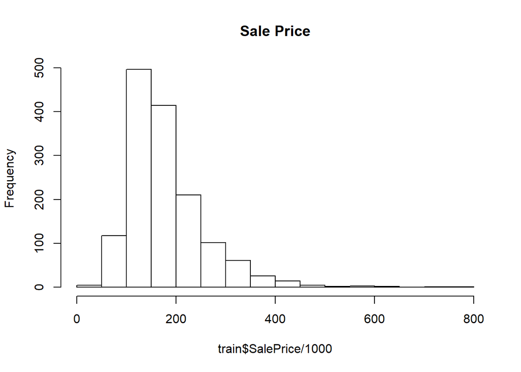

```r
hist(train$SalePrice/1000, main="Sale Price")
```

Visualment no sembla seguir una distribució normal

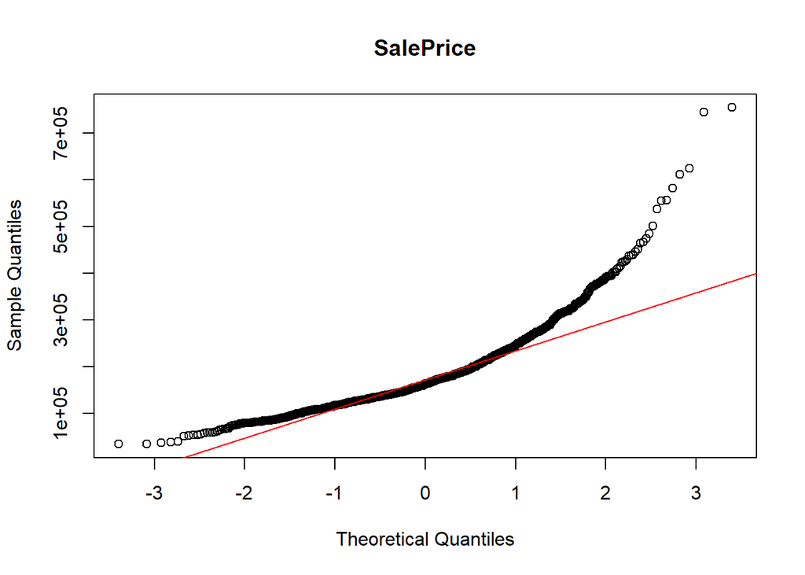

```r
qqnorm(train$SalePrice, main="SalePrice")
qqline(train$SalePrice,col=2)
```

Es confirma la manca de normalitat amb els tests de Kolmogorov-Smirnov i Shapiro-Wilk.

```r
ks.test(train$SalePrice, pnorm, mean(train$SalePrice), sd(train$SalePrice))
```

```
##
##  One-sample Kolmogorov-Smirnov test
##
## data:  train$SalePrice
## D = 0.12369, p-value < 2.2e-16
## alternative hypothesis: two-sided
```

```r
shapiro.test(train$SalePrice)
```

```
##
##  Shapiro-Wilk normality test
##
## data:  train$SalePrice
## W = 0.86967, p-value < 2.2e-16
```

veiem com el p-value és menor a 0.05, el qual vol dir que hem de refusa la Hipòtesi 0 i per tant podem confirmar que hi ha un manca de normalitat.

2-2- A continuació es fa la prova de normalitat de les variables numèriques usant el mètode de Shapiro-Wilk:

```r
library(nortest)
train <- as.data.frame(train)
##---- **** encara no funciona!
alpha = 0.05
col.names = colnames(train)
for (i in 1:ncol(train)) {
        if (i == 1) cat("Variables que no segueixen una distribució normal:\n")

        if (is.integer(train[,i]) | is.numeric(train[,i])) {

               #p_val = ad.test(train[,i])$p.value
                p_val = shapiro.test(train[,i])$p.value
                #  print(col.names[i])
               # print (p_val)
                if (p_val < alpha) {
                        cat (paste("No Normal: -- ", col.names[i]),"\r\n")
# Format output if (i < ncol(automoviles) - 1) cat(", ") if (i %% 3 == 0) cat("\n")
                }
               else{
                       cat (paste("Normal: -- ", col.names[i]),"\r\n")
               }

        }

}
```

```
## Variables que no segueixen una distribució normal:
## No Normal: --  Id
## No Normal: --  MSSubClass
## No Normal: --  LotFrontage
## No Normal: --  LotArea
## No Normal: --  OverallQual
## No Normal: --  OverallCond
## No Normal: --  YearBuilt
## No Normal: --  YearRemodAdd
## No Normal: --  MasVnrArea
## No Normal: --  BsmtFinSF1
## No Normal: --  BsmtFinSF2
## No Normal: --  BsmtUnfSF
## No Normal: --  TotalBsmtSF
## No Normal: --  1stFlrSF
## No Normal: --  2ndFlrSF
## No Normal: --  LowQualFinSF
## No Normal: --  GrLivArea
## No Normal: --  BsmtFullBath
## No Normal: --  BsmtHalfBath
## No Normal: --  FullBath
## No Normal: --  HalfBath
## No Normal: --  BedroomAbvGr
## No Normal: --  KitchenAbvGr
## No Normal: --  TotRmsAbvGrd
## No Normal: --  Fireplaces
## No Normal: --  GarageYrBlt
## No Normal: --  GarageCars
## No Normal: --  GarageArea
## No Normal: --  WoodDeckSF
## No Normal: --  OpenPorchSF
## No Normal: --  EnclosedPorch
## No Normal: --  3SsnPorch
## No Normal: --  ScreenPorch
## No Normal: --  PoolArea
## No Normal: --  MiscVal
## No Normal: --  MoSold
## No Normal: --  YrSold
## No Normal: --  SalePrice
```

Per tant sembla que cap de les variables numèriques no segueix una distribució normal.

2-3- Tot seguit, comprovem la correlació entre els diferents atributs numèrics respecte a l’atribut SalePrice, aplicant la funció cor() que genera una matriu amb els percentatges de correlació entre les variables seleccionades.

```r
cor(train[,c('OverallQual','OverallCond','YearBuilt','YearRemodAdd','MasVnrArea','BsmtFinSF1','BsmtFinSF2','BsmtUnfSF','TotalBsmtSF','1stFlrSF','2ndFlrSF','LowQualFinSF','GrLivArea','BsmtFullBath','BsmtHalfBath','FullBath','HalfBath','BedroomAbvGr','KitchenAbvGr','TotRmsAbvGrd','Fireplaces','GarageYrBlt','GarageCars','GarageArea','WoodDeckSF','OpenPorchSF','EnclosedPorch','3SsnPorch','ScreenPorch','PoolArea','MiscVal','MoSold','YrSold','SalePrice')], train['SalePrice'])
```

```
##                 SalePrice
## OverallQual    0.79098160
## OverallCond   -0.07785589
## YearBuilt      0.52289733
## YearRemodAdd   0.50710097
## MasVnrArea             NA
## BsmtFinSF1     0.38641981
## BsmtFinSF2    -0.01137812
## BsmtUnfSF      0.21447911
## TotalBsmtSF    0.61358055
## 1stFlrSF       0.60585218
## 2ndFlrSF       0.31933380
## LowQualFinSF  -0.02560613
## GrLivArea      0.70862448
## BsmtFullBath   0.22712223
## BsmtHalfBath  -0.01684415
## FullBath       0.56066376
## HalfBath       0.28410768
## BedroomAbvGr   0.16821315
## KitchenAbvGr  -0.13590737
## TotRmsAbvGrd   0.53372316
## Fireplaces     0.46692884
## GarageYrBlt            NA
## GarageCars     0.64040920
## GarageArea     0.62343144
## WoodDeckSF     0.32441344
## OpenPorchSF    0.31585623
## EnclosedPorch -0.12857796
## 3SsnPorch      0.04458367
## ScreenPorch    0.11144657
## PoolArea       0.09240355
## MiscVal       -0.02118958
## MoSold         0.04643225
## YrSold        -0.02892259
## SalePrice      1.00000000
```

En aquest cas com els atributs numèrics no segueixen una distribució normal, s’usa Spearman per a fer una matriu de correlació de les variables quantitatives amb la variable Sale Price. Prèviament es normalitzen els valors usant el mètode scale que usa una normalització de tipus z-score.

```r
train.scaled <- scale(train[,c('OverallQual','OverallCond','YearBuilt','YearRemodAdd','MasVnrArea','BsmtFinSF1','BsmtFinSF2','BsmtUnfSF','TotalBsmtSF','1stFlrSF','2ndFlrSF','LowQualFinSF','GrLivArea','BsmtFullBath','BsmtHalfBath','FullBath','HalfBath','BedroomAbvGr','KitchenAbvGr','TotRmsAbvGrd','Fireplaces','GarageYrBlt','GarageCars','GarageArea','WoodDeckSF','OpenPorchSF','EnclosedPorch','3SsnPorch','ScreenPorch','PoolArea','MiscVal','MoSold','YrSold','SalePrice')])
#es converteix a data frame
train.scaled <- as.data.frame(scale(train.scaled))
```

Spearman:

```r
corr_matrix <- matrix(nc = 2, nr = 0)
colnames(corr_matrix) <- c("estimate", "p-value")
for (i in 1:(ncol(train.scaled) - 1)) {
 if (is.integer(train.scaled[,i]) | is.numeric(train.scaled[,i])) {
   spearman_test = cor.test(train.scaled[,i],
   train.scaled[,length(train.scaled)], method = "spearman")
   corr_coef = spearman_test$estimate
   p_val = spearman_test$p.value
# Add row to matrix
   pair = matrix(ncol = 2, nrow = 1)
   pair[1][1] = corr_coef
   pair[2][1] = p_val
   corr_matrix <- rbind(corr_matrix, pair)
   rownames(corr_matrix)[nrow(corr_matrix)] <- colnames(train.scaled)[i]
  }
}
print(corr_matrix)
```

```
##                  estimate       p-value
## OverallQual    0.80982859  0.000000e+00
## OverallCond   -0.12932495  7.118552e-07
## YearBuilt      0.65268155 5.693841e-178
## YearRemodAdd   0.57115898 3.557233e-127
## MasVnrArea     0.42130950  1.472613e-63
## BsmtFinSF1     0.30187120  3.857909e-32
## BsmtFinSF2    -0.03880613  1.383221e-01
## BsmtUnfSF      0.18519663  9.886861e-13
## TotalBsmtSF    0.60272544 4.157300e-145
## 1stFlrSF       0.57540784 1.780246e-129
## 2ndFlrSF       0.29359799  2.040344e-30
## LowQualFinSF  -0.06771915  9.645078e-03
## GrLivArea      0.73130958 1.431015e-244
## BsmtFullBath   0.22512487  3.130150e-18
## BsmtHalfBath  -0.01218888  6.416775e-01
## FullBath       0.63595706 2.729574e-166
## HalfBath       0.34300755  1.422950e-41
## BedroomAbvGr   0.23490672  9.402132e-20
## KitchenAbvGr  -0.16482575  2.358516e-10
## TotRmsAbvGrd   0.53258594 9.553211e-108
## Fireplaces     0.51924745 1.354698e-101
## GarageYrBlt    0.59378833 3.611689e-132
## GarageCars     0.69071097 1.654517e-207
## GarageArea     0.64937853 1.320918e-175
## WoodDeckSF     0.35380161  2.688484e-44
## OpenPorchSF    0.47756066  4.860098e-84
## EnclosedPorch -0.21839362  3.180474e-17
## 3SsnPorch      0.06544022  1.238409e-02
## ScreenPorch    0.10006972  1.281429e-04
## PoolArea       0.05845300  2.551713e-02
## MiscVal       -0.06272700  1.652526e-02
## MoSold         0.06943224  7.955957e-03
## YrSold        -0.02989913  2.535700e-01
```

Les variables més fortament correlacionades, observades amb valors estimats més alts són:

OverallQual: Rates the overall material and finish of the house GrLivArea: Above grade (ground) living area square feet YearBuilt: Original construction date GarageCars: Size of garage in car capacity GarageArea: Size of garage in square feet

Les variables menys interessants són les que tenen una estimació més a prop de 0. Per tal de reduir la dimensionalitat es pot prescindir de les variables entre -0.2 i 0.2 que no tindrien massa correlació amb el Sale Price:

OverallCond BsmtFinSF2 BsmtUnfSF LowQualFinSF BsmtHalfBath KitchenAbvGr 3SsnPorch ScreenPorch PoolArea MiscVal  
MoSold YrSold

```r
train = subset(train, select = -c(OverallCond,BsmtFinSF2,BsmtUnfSF,LowQualFinSF,
BsmtHalfBath,BsmtHalfBath,KitchenAbvGr,`3SsnPorch`,ScreenPorch,PoolArea,
MiscVal,MoSold,YrSold) )
```

# Tractament d’outliers

IDENTIFICACIÓ:

1-Variable de classe-dependent: Sale Price

```r
summary(train$SalePrice)
```

```
##    Min. 1st Qu.  Median    Mean 3rd Qu.    Max.
##   34900  129975  163000  180921  214000  755000
```

```r
boxplot.stats(train$SalePrice)$out
```

```
##  [1] 345000 385000 438780 383970 372402 412500 501837 475000 386250 403000
## [11] 415298 360000 375000 342643 354000 377426 437154 394432 426000 555000
## [21] 440000 380000 374000 430000 402861 446261 369900 451950 359100 345000
## [31] 370878 350000 402000 423000 372500 392000 755000 361919 341000 538000
## [41] 395000 485000 582933 385000 350000 611657 395192 348000 556581 424870
## [51] 625000 392500 745000 367294 465000 378500 381000 410000 466500 377500
## [61] 394617
```

```r
train.data = train[c("OverallQual","GrLivArea","YearBuilt","GarageCars","GarageArea","SalePrice")]


filter(train.data,SalePrice %in% (boxplot.stats(train$SalePrice)$out))
```

```
##    OverallQual GrLivArea YearBuilt GarageCars GarageArea SalePrice
## 1            9      2324      2005          3        736    345000
## 2            9      1842      1981          3        894    385000
## 3           10      2945      2006          3        641    438780
## 4            7      2696      2007          3        792    383970
## 5            8      1710      2007          3        866    372402
## 6            9      2668      2003          3        726    412500
## 7            9      2234      2008          3       1166    501837
## 8           10      3608      1892          3        840    475000
## 9           10      2392      2003          3        968    386250
## 10           8      2794      1995          3        810    403000
## 11           9      2121      2006          3        732    415298
## 12           9      1944      2003          3        708    360000
## 13           7      2036      1965          2        513    375000
## 14           9      2596      2006          3        840    342643
```

[output cut: 47 more lines]

2-Variables independents:

Probablement són cases de finals del segle XIX.

```r
boxplot.stats(train$YearBuilt)$out
```

```
## [1] 1880 1880 1880 1882 1880 1875 1872
```

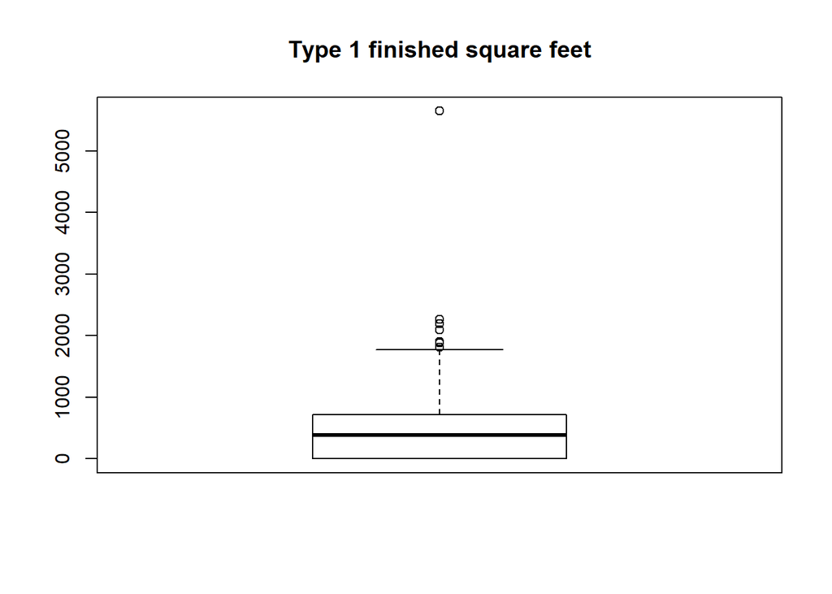

```r
bp <-boxplot(train$BsmtFinSF1,main="Type 1 finished square feet")
```

```r
bp$out
```

```
## [1] 1810 1880 1904 2260 2188 2096 5644
```

```r
#boxplot.stats(train$BsmtFinSF1)$out
```

```r
boxplot.stats(train$TotalBsmtSF)$out
```

```
##  [1]    0    0 2223    0    0    0 2216    0 2392    0 2121 2136 3206    0
## [15]    0    0    0 3094 2153 3200    0 3138    0    0    0    0 2109 2077
## [29] 2444    0    0    0    0 2078    0 2217    0    0 2330    0    0    0
## [43]    0 2524    0    0    0    0    0 2396 2158    0    0 2136    0 2076
## [57] 2110 6110    0 2633    0
```

Hi ha o un total de metres quadrats de la basement area (sotan) molt gran > 2000 o bé no hi ha sòtan i és 0

```r
boxplot.stats(train$`1stFlrSF`)$out
```

```
##  [1] 2207 2223 2259 2158 2234 2392 2402 3228 3138 2515 2444 2217 2364 2898
## [15] 2524 2411 2196 4692 2156 2633
```

```r
boxplot.stats(train$`2ndFlrSF`)$out
```

```
## [1] 1872 2065
```

```r
boxplot.stats(train$GrLivArea)$out
```

```
##  [1] 2945 3222 3608 3112 2794 3493 2978 3228 4676 2775 3194 3395 4316 3279
## [15] 3140 2822 2872 2898 3082 2868 2828 3627 3086 2872 4476 3447 5642 2810
## [29] 2792 3238 2784
```

```r
boxplot.stats(train$TotRmsAbvGrd)$out
```

```
##  [1] 11 11 12 11 11 11 11 14 11 12 11 12 11 11 12 11 12 11 12 11 11 12 12
## [24] 11 11 12 12 12 11 11
```

```r
boxplot.stats(train$Bedroom)$out
```

```
##  [1] 0 5 5 6 0 5 6 5 5 6 5 6 5 0 8 5 6 5 5 6 5 5 5 5 5 5 5 0 0 5 0 5 6 5 5
```

```r
boxplot.stats(train$Fireplaces)$out
```

```
## [1] 3 3 3 3 3
```

```r
boxplot.stats(train$GarageYrBlt)$out
```

```
## numeric(0)
```

```r
boxplot.stats(train$GarageCars)$out
```

```
## [1] 4 4 4 4 4
```

```r
boxplot.stats(train$GarageArea)$out
```

```
##  [1] 1166  968 1053 1025  947 1390 1134  983 1020 1220 1248 1043 1052  995
## [15] 1356 1052  954 1014 1418  968 1069
```

```r
boxplot.stats(train$WoodDeckSF)$out
```

```
##  [1] 857 576 476 574 441 468 670 495 536 519 466 517 426 503 486 486 511
## [18] 421 550 509 474 728 436 431 448 439 635 500 668 586 431 736
```

(Wood deck area in square feet outliers)

```r
boxplot.stats(train$OpenPorchSF)$out
```

```
##  [1] 204 213 258 199 234 184 205 228 238 260 198 172 208 228 184 250 175
## [18] 195 214 231 192 187 176 523 285 406 182 502 274 172 243 235 312 267
## [35] 265 288 341 204 174 247 291 312 418 240 364 188 207 234 192 191 252
## [52] 189 282 224 319 244 185 200 180 263 304 234 240 192 229 211 198 287
## [69] 292 207 241 547 211 184 262 210 236
```

(Open porch area in square feet outliers)

```r
boxplot.stats(train$EnclosedPorch)$out
```

```
##   [1] 272 228 205 176 205  87 172 102  37 144  64 114 202 128 156  44  77
##  [18] 144 192 144 140 180 228 128 183  39 184  40 552  30 126  96  60 150
##  [35] 120 202  77 112 252  52 224 234 144 244 268 137  24 108 294 177 218
##  [52] 242  91 112 160 130 184 126 169 105  34  96 248 236 120  32  80 115
##  [69] 291 184 116 158 112 210  36 156 144 200  84 148 116 120 136 102 240
##  [86]  54 112  39 100  36 189 293 164  40 216 239 112 252 240 180  67  90
## [103] 120  56 112 129  40  98 143 216 234 112 112  70 386 154 185 156 156
## [120] 134 196 264 185 275  96 120 112 116 230 254  68 194 192  34 150 164
## [137] 112 224  32 318 244  48  94 138 108 112 226 192 174 228  19 170 220
## [154] 128  80 115 137 192 252 112  96 176 216 176 214 280  96 116 102 190
## [171] 236 192  84 330 208 145 259 126 264  81 164  42 123 162 100 286 190
## [188] 168  20 301 198  96 221 112 212  50 150 168 112 160 114 216 154  99
## [205] 158 216 252 112
```

Enclosed porch area in square feet outliers: La mitja són 21.95 i el màxim 552 no havent-hi ni primer ni tercer quartil. Per tant podem dir que en la majoria de casos no hi ha enclosed porch, però quan hi ha és de molts metres quadrats.

TRACTAMENT d’OUTLIERS: Tots el outliers analitzats tenen sentint dintre del domini de cada atribut, per tant es decideix no aplicar cap mètode corrector.

# CREACIÓ DE NOVES VARIABLES NUMÈRIQUES A PARTIR DE LES CATEGÒRIQUES

Abans hem trobat la correlació de les variables numèriques amb SalePrice fent servir la funció cor() i la correlació d’Spearman. Ara, intentarem fer el mateix però amb les variables categòriques.

Per tal d’aconseguir-ho crearem nous atributs numèrics a partir dels atributs categòrics existents. Això ho podrem fer revisant cadascuna de les variables i definint uns valors numèrics que descriguin de forma equivalent les categories representades.

La nomenclatura que farem servir per assignar aquests nous atributs serà **vn** al principi del nom, per tal d’indicar que es tracta d’un valor numèric.

Començarem per la variable Street, que té dos possibles valors: Grvl o Pave; és a dir el camí d’accés a la vivenda pot ser de grava o pavimentat.

```
##
## Grvl Pave
##    6 1454
```

L’atribut LotShape ens descriu la forma de la vivenda en 4 nivells desde regular (millor) fins a irregular (pitjor).

```
##
## IR1 IR2 IR3 Reg
## 484  41  10 925
```

LandContour indica el desnivell de la vivenda.

```
##
##  Bnk  HLS  Low  Lvl
##   63   50   36 1311
```

Utilities descriu els serveis de que consta la vivenda.

```
##
## AllPub NoSeWa
##   1459      1
```

LandSlope indica el pendent del terreny.

```
##
##  Gtl  Mod  Sev
## 1382   65   13
```

Amb LotConfig per tal de donar un valor numèric que tingui sentit, tenint en compte que no es pot establir cap ordre de millor o pitjor per a la configuració de la propietat, el que farem es fixar-nos en el preu mig per a cada tipus de configuració. D’aquesta manera podrem ordenar de la configuració més cara a la més barata les vivendes.

```
## # A tibble: 5 x 2
##   LotConfig `mean(SalePrice, na.rm = T)`
##   <chr>                            <dbl>
## 1 Corner                         181623.
## 2 CulDSac                        223855.
## 3 FR2                            177935.
## 4 FR3                            208475
## 5 Inside                         176938.
```

Per assignar un valor numèric a l’atribut Neighborhood farem el mateix. Definirem el preu mig de venta de les vivendes de cada veïnat, i a continuació classificarem aquests barris en 3 grups en funció del preu mig de les vivendes entre barats(1), preu mitjà(2) i cars(3).

Els atributs Condition1 i Condition2 els convertirem a valors numèrics d’igual forma. I farem servir el mateix mètode que en els anteriors casos, comprovant el preu de venta mig per a cadascuna de les categories i establint un ordre per a que els valors numèrics tinguin sentit.

```
## # A tibble: 9 x 2
##   Condition1 `mean(SalePrice, na.rm = T)`
##   <chr>                             <dbl>
## 1 Artery                          135092.
## 2 Feedr                           142475.
## 3 Norm                            184495.
## 4 PosA                            225875
## 5 PosN                            215184.
## 6 RRAe                            138400
## 7 RRAn                            184397.
## 8 RRNe                            190750
## 9 RRNn                            212400
```

```
## # A tibble: 8 x 2
##   Condition2 `mean(SalePrice, na.rm = T)`
##   <chr>                             <dbl>
## 1 Artery                          106500
## 2 Feedr                           121167.
## 3 Norm                            181169.
## 4 PosA                            325000
## 5 PosN                            284875
## 6 RRAe                            190000
## 7 RRAn                            136905
## 8 RRNn                             96750
```

BldgType indica el tipus de construcció

```
## # A tibble: 5 x 2
##   BldgType `mean(SalePrice, na.rm = T)`
##   <chr>                           <dbl>
## 1 1Fam                          185764.
## 2 2fmCon                        128432.
## 3 Duplex                        133541.
## 4 Twnhs                         135912.
## 5 TwnhsE                        181959.
```

HouseStyle descriu el tipus de vivenda

RoofStyle descriu el tipus de teulada.

```
## # A tibble: 6 x 2
##   RoofStyle `mean(SalePrice, na.rm = T)`
##   <chr>                            <dbl>
## 1 Flat                           194690
## 2 Gable                          171484.
## 3 Gambrel                        148909.
## 4 Hip                            218877.
## 5 Mansard                        180568.
## 6 Shed                           225000
```

RoofMatl descriu el material amb que està feta la teulada.

```
## # A tibble: 8 x 2
##   RoofMatl `mean(SalePrice, na.rm = T)`
##   <chr>                           <dbl>
## 1 ClyTile                       160000
## 2 CompShg                       179804.
## 3 Membran                       241500
## 4 Metal                         180000
## 5 Roll                          137000
## 6 Tar&Grv                       185406.
## 7 WdShake                       241400
## 8 WdShngl                       390250
```

Exterior1st i Exterior2nd descriuen el tipus d’acabats del recobriment exterior de les parets de la vivenda.

MasVnrType indica el tipus de mamposteria.

```
## # A tibble: 5 x 2
##   MasVnrType `mean(SalePrice, na.rm = T)`
##   <chr>                             <dbl>
## 1 BrkCmn                          146318.
## 2 BrkFace                         204692.
## 3 None                            156222.
## 4 Stone                           265584.
## 5 <NA>                            236484.
```

Observem que hi han valors NA.

ExterQual, ens diu la qualitat dels materials emprats en els exteriors.

ExterCond indica l’estat actual dels materials emprats en els exteriors.

Foundation indica el tipus de fonaments de la vivenda.

```
## # A tibble: 6 x 2
##   Foundation `mean(SalePrice, na.rm = T)`
##   <chr>                             <dbl>
## 1 BrkTil                          132291.
## 2 CBlock                          149806.
## 3 PConc                           225230.
## 4 Slab                            107366.
## 5 Stone                           165959.
## 6 Wood                            185667.
```

BsmtQual, indica la qualitat del soterrani en funció de la seva alçada.

BsmtCond, fa una evaluació general de les condicions actuals del soterrani.

BsmtExposure fa referència a la visibilitat del soterrani.

BsmtFinType1 i BsmtFinType2 fa referència a la qualitat del soterrani i la seva habitabilitat.

Heating descriu el tipus de calefacció.

```
## # A tibble: 6 x 2
##   Heating `mean(SalePrice, na.rm = T)`
##   <chr>                          <dbl>
## 1 Floor                         72500
## 2 GasA                         182021.
## 3 GasW                         166632.
## 4 Grav                          75271.
## 5 OthW                         125750
## 6 Wall                          92100
```

HeatingQC ens diu la qualitat i l’estat de la instal·lació de la calefacció.

CentralAir indica si l’habitatge té aire acondicionat central.

Electrical descriu el tipus d’instal·lació elèctrica de la vivenda.

```
## # A tibble: 6 x 2
##   Electrical `mean(SalePrice, na.rm = T)`
##   <chr>                             <dbl>
## 1 FuseA                           122197.
## 2 FuseF                           107675.
## 3 FuseP                            97333.
## 4 Mix                              67000
## 5 SBrkr                           186825.
## 6 <NA>                            167500
```

KitchenQual, valora la qualitat general de la cuina.

FireplaceQu, indica la qualitat del foc a terra.

GarageType, tipus de garatge.

```
## # A tibble: 7 x 2
##   GarageType `mean(SalePrice, na.rm = T)`
##   <chr>                             <dbl>
## 1 2Types                          151283.
## 2 Attchd                          202893.
## 3 Basment                         160571.
## 4 BuiltIn                         254752.
## 5 CarPort                         109962.
## 6 Detchd                          134091.
## 7 <NA>                            103317.
```

GarageFinish, ens diu si l’interior del garatge està acabat o no.

GarageQual, indica la qualitat general del garatge.

GarageCond, indica l’estat actual del garatge.

PavedDrive indica si la calçada està asfaltada.

Functional, indica la funcionalitat de l’habitatge (assumeix la opció Typical si no hi ha cap deducció garantida).

SaleType fa referència al tipus de venta.

```
## # A tibble: 9 x 2
##   SaleType `mean(SalePrice, na.rm = T)`
##   <chr>                           <dbl>
## 1 COD                           143973.
## 2 Con                           269600
## 3 ConLD                         138781.
## 4 ConLI                         200390
## 5 ConLw                         143700
## 6 CWD                           210600
## 7 New                           274945.
## 8 Oth                           119850
## 9 WD                            173402.
```

SaleCondition descriu les condicions en que s’ha realitzat la venta.

```
## # A tibble: 6 x 2
##   SaleCondition `mean(SalePrice, na.rm = T)`
##   <chr>                                <dbl>
## 1 Abnorml                            146527.
## 2 AdjLand                            104125
## 3 Alloca                             167377.
## 4 Family                             149600
## 5 Normal                             175202.
## 6 Partial                            272292.
```

MSZoning identifica el tipus de zona on es realitza la venta.

```
## # A tibble: 5 x 2
##   MSZoning `mean(SalePrice, na.rm = T)`
##   <chr>                           <dbl>
## 1 C (all)                        74528
## 2 FV                            214014.
## 3 RH                            131558.
## 4 RL                            191005.
## 5 RM                            126317.
```

MSSubClass identifica el tipus de vivenda venuda.

A continuació s’observala correlació, donat que a les variables numèriques no seguien una distribució normal, s’aplica també Spearman sobre les variables transformades vn, afegint SalePrice al final com a variable dependent

```r
train.vn <- train[,c("vnStreet","vnLotShape","vnLandContour","vnUtilities",
"vnLandSlope","vnLotConfig","vnNeighborhood","vnCondition1","vnCondition2","vnBldgType",
"vnHouseStyle","vnRoofStyle","vnRoofMatl","vnExterior1st","vnExterior2nd",
"vnMasVnrType","vnExterQual","vnExterCond","vnFoundation","vnBsmtQual","vnBsmtCond",
"vnBsmtExposure" ,"vnBsmtFinType1","vnBsmtFinType2","vnHeating","vnHeatingQC",
"vnCentralAir","vnElectrical","vnKitchenQual" ,"vnFireplaceQu","vnGarageType",
"vnGarageFinish","vnGarageQual","vnGarageCond","vnPavedDrive","vnFunctional",
"vnSaleCondition","SalePrice")]
```

Spearman en les variables vn

```r
corr_matrix <- matrix(nc = 2, nr = 0)
colnames(corr_matrix) <- c("estimate", "p-value")
for (i in 1:(ncol(train.vn) - 1)) {
# if( substr(colnames(train.vn[i]), start=1, stop=2)=="vn")
 # {
   spearman_test = cor.test(train.vn[,i],
   train.vn[,length(train.vn)], method = "spearman")
   corr_coef = spearman_test$estimate
   p_val = spearman_test$p.value
# Add row to matrix
   pair = matrix(ncol = 2, nrow = 1)
   pair[1][1] = corr_coef
   pair[2][1] = p_val
   corr_matrix <- rbind(corr_matrix, pair)
   rownames(corr_matrix)[nrow(corr_matrix)] <- colnames(train.vn)[i]
  #}
}
print(corr_matrix)
```

```
##                    estimate       p-value
## vnStreet         0.04581419  8.012225e-02
## vnLotShape      -0.32105533  2.341724e-36
## vnLandContour   -0.01789297  4.945066e-01
## vnUtilities      0.01670961  5.234926e-01
## vnLandSlope     -0.05031026  5.461545e-02
## vnLotConfig      0.10502919  5.798914e-05
## vnNeighborhood   0.68525784 5.403916e-203
## vnCondition1     0.09586658  2.441008e-04
## vnCondition2     0.05517806  3.501794e-02
## vnBldgType       0.11570952  1.262589e-05
## vnHouseStyle     0.31338851  1.236615e-34
## vnRoofStyle      0.16378164  3.068415e-10
## vnRoofMatl       0.11053654  2.306410e-05
## vnExterior1st    0.41592760  3.653377e-62
## vnExterior2nd    0.41265735  3.997079e-61
## vnMasVnrType     0.41061097  1.762322e-60
## vnExterQual      0.68401380 5.605572e-202
## vnExterCond      0.01168189  6.555992e-01
## vnFoundation     0.57358006 1.755079e-128
## vnBsmtQual       0.67802625 3.696559e-197
## vnBsmtCond       0.26937252  1.088293e-25
## vnBsmtExposure   0.34420665  7.175863e-42
## vnBsmtFinType1   0.36162475  2.443878e-46
## vnBsmtFinType2   0.03981255  1.283765e-01
## vnHeating        0.12194854  2.966772e-06
## vnHeatingQC      0.49139191  1.347224e-89
## vnCentralAir     0.31328617  1.302833e-34
## vnElectrical     0.29757768  3.074431e-31
## vnKitchenQual    0.67284855 4.400509e-193
## vnFireplaceQu    0.53760183 3.933062e-110
## vnGarageType     0.59881437 8.906579e-143
## vnGarageFinish   0.63397362 5.937952e-165
## vnGarageQual     0.35108157  1.336417e-43
## vnGarageCond     0.33901490  1.360807e-40
## vnPavedDrive     0.28060152  8.018188e-28
## vnFunctional     0.13498257  2.255201e-07
## vnSaleCondition  0.31498304  6.752142e-35
```

Les variables categòriques més correlacionades amb el Preu són:

vnNeighborhood: Barri. (Agrupació de barris en 3 grups segons el preu mitjà de les cases.) vnExterQual: Qualtitat del material al exterior  
vnKitchenQual: Qualitat de la cuina vnBsmtQual: Evalua el gruix del pis que està directament relacionat amb la qualitat. vnGarageFinish: Mesura la qualitat del garatge

Recordem també les variables numèriques més correlacionades eren:

OverallQual: Rates the overall material and finish of the house GrLivArea: Above grade (ground) living area square feet YearBuilt: Original construction date GarageCars: Size of garage in car capacity GarageArea: Size of garage in square feet

A continuació s’analitza la colinealitat entre aquestes variables en dos cops:

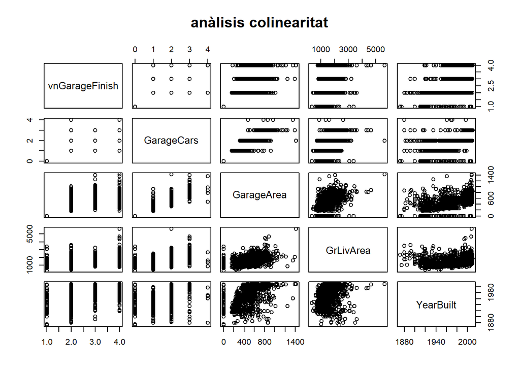

```r
pairs(~vnGarageFinish+GarageCars+GarageArea+GrLivArea+YearBuilt,data=train,
   main="anàlisis colinearitat")
```

S’observa certa correlació entre Garage Area i YearBuilt.

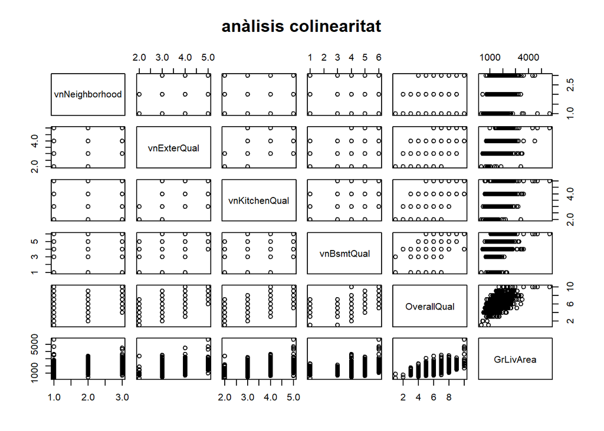

```r
pairs(~vnNeighborhood+vnExterQual+vnKitchenQual+vnBsmtQual+
        OverallQual+GrLivArea,data=train,
   main="anàlisis colinearitat")
```

s’observa una colinearitat molt més clara entre GrLivArea i OverallQual.

# Comparació de barris en relació al preu de venda (Comparació de grups)

A la fase de creació de variables numèriques a partir de qualitatives es va veure que es podia establir un ordre en els barris d’acord amb el seu preu mitjà. A continuació es fa una prova d’hipòtesi per a comparar aquests barris com grups i determinar si són iguals en quant a la seva mitjana i homoscedasticitat. Com ja vam veure, la variable SalePrice no seguexi una distribució normal, a continuació es fa la prova d’homoscedasticitat amb el test de Fligner-Killeen.

Establim com a Hipòtesi 0 que les variances són iguals amb un nivell de confiança d’un 95% (nivell de significació per defecte 0.05)

```r
 fligner.test(SalePrice ~ Neighborhood, data = train)
```

```
##
##  Fligner-Killeen test of homogeneity of variances
##
## data:  SalePrice by Neighborhood
## Fligner-Killeen:med chi-squared = 282.78, df = 24, p-value <
## 2.2e-16
```

Com que el p-value <0.05 es rebutja la hipòtesi nul·la i per tant podem dir que el preu de venda presenta variàncies estadísticament diferents segons el barri.

A continuació es compara d’una forma no paramètrica les distribucions dels barris que van ser categoritzats com grup 1 i grup 2 aplicant el test de Wilcox.

```r
  wilcox.test(SalePrice ~ vnNeighborhood, data = train, subset = vnNeighborhood <3)
```

```
##
##  Wilcoxon rank sum test with continuity correction
##
## data:  SalePrice by vnNeighborhood
## W = 52771, p-value < 2.2e-16
## alternative hypothesis: true location shift is not equal to 0
```

Per tant es comprova d’una manera més formal, que es refusa la hipòtesi nul·la perquè p-vale <0.05 que els grups de barris 1 i 2 són estadísticament diferents en quan al preu de venda de les cases.

Cada barri està en un grup (segons la mitja de preus de venda. Grup 1 amb els barris que tenen les cases més barates, grup 3: barris amb les cases més cares)

```r
unique ((train[c("vnNeighborhood","Neighborhood")]))
```

```
##     vnNeighborhood Neighborhood
## 1                2      CollgCr
## 2                3      Veenker
## 4                3      Crawfor
## 5                3      NoRidge
## 6                2      Mitchel
## 7                3      Somerst
## 8                2       NWAmes
## 9                1      OldTown
## 10               1      BrkSide
## 11               1       Sawyer
## 12               3      NridgHt
## 15               2        NAmes
## 19               2      SawyerW
## 22               1       IDOTRR
## 24               1      MeadowV
## 40               1      Edwards
## 42               3       Timber
## 51               2      Gilbert
## 59               3      StoneBr
## 70               3      ClearCr
## 127              2      NPkVill
## 220              2      Blmngtn
## 226              1       BrDale
## 268              2        SWISU
## 600              1      Blueste
```

s’analitza visualment per OverallQual (ratis de qualitat en quant acabats de la casa) els barris relacionats.

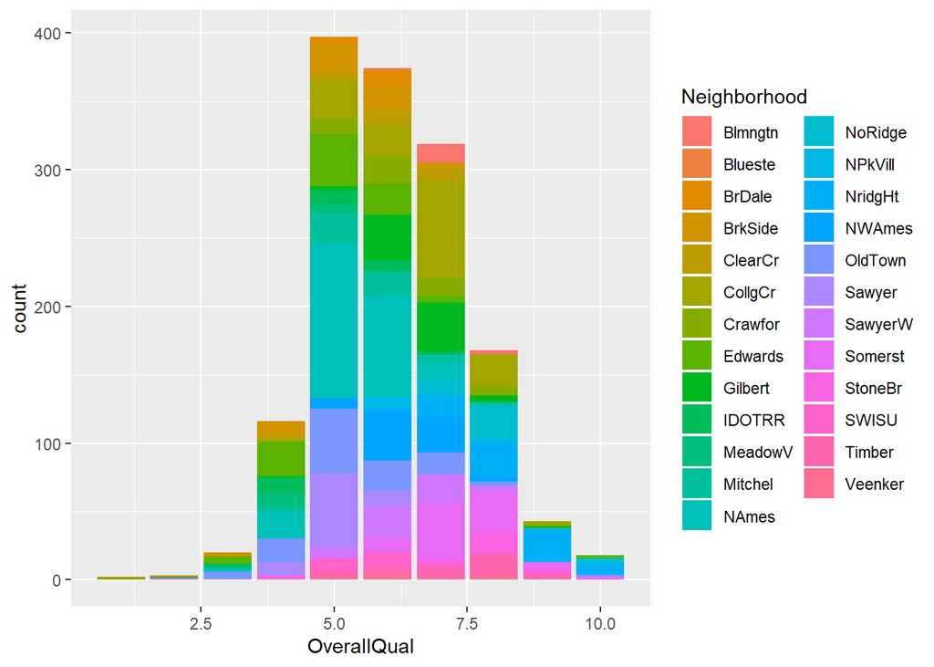

```r
filas=dim(train)[1] #1460 rows
ggplot(data=train[1:filas,],aes(x=OverallQual,fill=Neighborhood))+geom_bar()
```

S’observa per exemple que la relació de qualitat de la casa en els valors de 9-10 està present en els barris del grup 3.

# Comparació de preus de cases per decada de construcció de la casa

Hi ha una diferència entre els preus de venda dels anys 80 als anys 90? Creació dels subsets:

```r
train.SalePrice80s <-train$SalePrice[train$YearBuilt >1979 & train$YearBuilt <=1989]
train.SalePrice90s <-train$SalePrice[train$YearBuilt >1989 & train$YearBuilt <=2000]
```

Es comprova la normalitat, donat que serien subsets de la variable SalePrice. S’usa el mètode de Kolmogorov-Smirnov

```r
ks.test(train.SalePrice80s, pnorm, mean(train.SalePrice80s), sd(train.SalePrice80s))
```

```
##
##  One-sample Kolmogorov-Smirnov test
##
## data:  train.SalePrice80s
## D = 0.13989, p-value = 0.1836
## alternative hypothesis: two-sided
```

Assumint com a hipòtesi nul·la que la població està distribuïda normalment, Al ser el p-valor més gran que el nivell de significació,(per defecte α=0,05) la hipòtesi nul·la no es podria rebutjar i amb un 95% de confiança podríem dir que la distribució és normal.

Ara bé, passant el test de shapiro, la hipòtesi nul·la sí s’hauria de rebutjar:

```r
shapiro.test(train.SalePrice80s)
```

```
##
##  Shapiro-Wilk normality test
##
## data:  train.SalePrice80s
## W = 0.91085, p-value = 0.000298
```

Es comprova si en la decada dels 90 els preus segueixen una distribució normal

```r
ks.test(train.SalePrice90s, pnorm, mean(train.SalePrice90s), sd(train.SalePrice90s))
```

```
##
##  One-sample Kolmogorov-Smirnov test
##
## data:  train.SalePrice90s
## D = 0.15275, p-value = 0.0003244
## alternative hypothesis: two-sided
```

Segons Kolmogorov-Smirnov, la distribució dels 90 no seria normal. Es comprova com tampoc ho és seguint Shapiro-Wilk.

```r
shapiro.test(train.SalePrice90s)
```

```
##
##  Shapiro-Wilk normality test
##
## data:  train.SalePrice90s
## W = 0.72836, p-value < 2.2e-16
```

Es fa el test d’homoscedasticitat per a comprovar si les variances són iguals. Es comprova l’anàlisi de variances amb el test no paramètric de Fligner. Com que el nombre d’elements en cada sample és diferent es fa un stack previ en un nou dataframe anomenat stacked:

```r
stacked <- stack(list(train.SalePrice80s=train.SalePrice80s,train.SalePrice90s=train.SalePrice90s))
 fligner.test(values ~ ind, data = stacked)
```

```
##
##  Fligner-Killeen test of homogeneity of variances
##
## data:  values by ind
## Fligner-Killeen:med chi-squared = 0.37698, df = 1, p-value =
## 0.5392
```

Segons el test de Fligner-Killeen les variances seguirien una distribució similar entre SalesPrice 80 i 90.

Es comparen els preus dels 80s amb els 90s seguint el test no paramètric de Wilcoxon i Mann-Whitney. La hipòtesi nul·la seria la igualtat de les distribucions :

```r
stacked <- stack(list(train.SalePrice80s=train.SalePrice80s,train.SalePrice90s=train.SalePrice90s))
wilcox.test(values ~ ind, data = stacked)
```

```
##
##  Wilcoxon rank sum test with continuity correction
##
## data:  values by ind
## W = 3909.5, p-value = 0.0002273
## alternative hypothesis: true location shift is not equal to 0
```

```r
#wilcox.test(values ~ ind, data = stacked, subset = Month %in% c(5, 8))
```

Donat que el test dona un p-value < 0.05, s’hauria de rebutjar la hipòtesi nul·la i per tant concloure que els preus són estadísticament diferents entre els 80 i els 90s

Donat que alguns tests són positius i altres negatius, es fa una representació visual també. Es pot concloure que la mitja del preu de venda, tot i diferent, no pujaria excessivament dels 80s als 90s. Possiblement un dels factors que està impactant en la comparació paramètrica dels preus, serien alguns preus molt alts (Outliers) trobats en la dècada dels 90.

```r
# Plot
summary(train.SalePrice80s)
```

```
##    Min. 1st Qu.  Median    Mean 3rd Qu.    Max.
##  112000  143000  178000  190080  215000  385000
```

```r
summary(train.SalePrice90s)
```

```
##    Min. 1st Qu.  Median    Mean 3rd Qu.    Max.
##   93500  177250  204000  226141  250500  755000
```

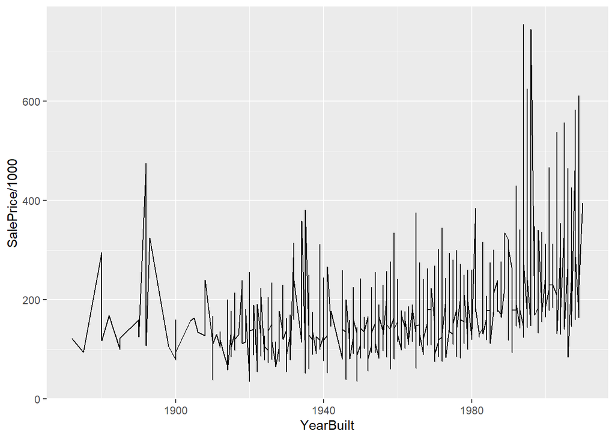

```r
# Plot
ggplot(train, aes(x=YearBuilt, y=SalePrice/1000)) +
  geom_line()
```

# Model 1: Regressió Lineal

Es fa una aproximació de la relació de dependència lineal entre la variable a predir: Sale Price i un subset de variables abans identificades com més correlacionades amb SalesPrice.

```r
lmSalePrice1  = lm(SalePrice~OverallQual+YearBuilt+vnNeighborhood+vnKitchenQual
                  +FullBath+GarageCars+GarageArea+GrLivArea,data=train)
#summary(lmSalePrice)
```

Veiem com usant les variables originals el R-Squared millora, sent de 8.1.

```r
lmSalePrice2  = lm(SalePrice~OverallQual+YearBuilt+Neighborhood+KitchenQual
                  +FullBath+GarageCars+GarageArea+GrLivArea,data=train)
#summary(lmSalePrice)
```

```r
lmSalePrice3  = lm(SalePrice~FullBath+YearBuilt+vnNeighborhood+vnKitchenQual
                  +OverallQual+GarageFinish+GrLivArea,data=train)
#summary(lmSalePrice)$r.squared
```

```r
lmSalePrice4  = lm(SalePrice~FullBath+YearBuilt+Neighborhood+KitchenQual
                  +OverallQual+GarageFinish+GrLivArea+ExterQual+BsmtQual+TotalBsmtSF,data=train)
```

```r
lmSalePrice5  = lm(SalePrice~MSSubClass+MSZoning+Neighborhood+KitchenQual
                  +OverallQual+GarageFinish+GrLivArea+ExterQual+BsmtQual+TotalBsmtSF+
                    LotArea+LotShape+LandContour+BldgType+HouseStyle+
                    YearRemodAdd+Exterior1st+ExterQual+Foundation+HalfBath+
                    BedroomAbvGr+Fireplaces+FireplaceQu+
                    GarageCars+GarageArea+GarageQual+PavedDrive+WoodDeckSF+OpenPorchSF
                   ,data=train)
```

```r
print (paste("Model 1 -->", summary(lmSalePrice1)$r.squared))
```

```
## [1] "Model 1 --> 0.782895088977925"
```

```r
print (paste("Model 2 -->", summary(lmSalePrice2)$r.squared))
```

```
## [1] "Model 2 --> 0.819081072671528"
```

```r
print (paste("Model 3 -->", summary(lmSalePrice3)$r.squared))
```

```
## [1] "Model 3 --> 0.770873063098381"
```

```r
print (paste("Model 4 -->", summary(lmSalePrice4)$r.squared))
```

```
## [1] "Model 4 --> 0.824611474027129"
```

```r
print (paste("Model 5 -->", summary(lmSalePrice4)$r.squared))
```

```
## [1] "Model 5 --> 0.824611474027129"
```

```r
# no hi ha guany significatiu afegint més variables print (paste("Model 5 -->", summary(lmSalePrice5)$r.squared))
```

```r
summary(lmSalePrice4)
```

```
##
## Call:
## lm(formula = SalePrice ~ FullBath + YearBuilt + Neighborhood +
##     KitchenQual + OverallQual + GarageFinish + GrLivArea + ExterQual +
##     BsmtQual + TotalBsmtSF, data = train)
##
## Residuals:
##     Min      1Q  Median      3Q     Max
## -426134  -14303     -41   13595  215198
##
## Coefficients:
##                       Estimate Std. Error t value Pr(>|t|)
## (Intercept)         -1.766e+05  1.653e+05  -1.069 0.285452
## FullBath             5.053e+02  2.694e+03   0.188 0.851232
## YearBuilt            1.348e+02  8.231e+01   1.637 0.101828
## NeighborhoodBlueste -1.365e+04  2.542e+04  -0.537 0.591416
## NeighborhoodBrDale  -1.909e+04  1.273e+04  -1.499 0.134033
## NeighborhoodBrkSide  6.293e+03  1.104e+04   0.570 0.568674
## NeighborhoodClearCr  3.715e+04  1.104e+04   3.365 0.000788 ***
## NeighborhoodCollgCr  1.979e+04  8.838e+03   2.239 0.025310 *
## NeighborhoodCrawfor  3.427e+04  1.055e+04   3.247 0.001197 **
## NeighborhoodEdwards -1.184e+04  9.934e+03  -1.192 0.233637
## NeighborhoodGilbert  1.171e+04  9.258e+03   1.264 0.206281
## NeighborhoodIDOTRR  -5.328e+03  1.183e+04  -0.450 0.652458
## NeighborhoodMeadowV -1.411e+04  1.333e+04  -1.058 0.290336
## NeighborhoodMitchel  9.424e+03  1.020e+04   0.924 0.355696
## NeighborhoodNAmes    6.517e+03  9.479e+03   0.688 0.491869
## NeighborhoodNoRidge  7.711e+04  1.013e+04   7.609 5.25e-14 ***
## NeighborhoodNPkVill  2.507e+02  1.438e+04   0.017 0.986089
## NeighborhoodNridgHt  4.474e+04  9.541e+03   4.689 3.03e-06 ***
## NeighborhoodNWAmes   9.735e+03  9.666e+03   1.007 0.314024
## NeighborhoodOldTown -7.763e+03  1.068e+04  -0.727 0.467255
## NeighborhoodSawyer   1.064e+04  9.997e+03   1.064 0.287582
## NeighborhoodSawyerW  1.685e+04  9.647e+03   1.747 0.080937 .
## NeighborhoodSomerst  2.393e+04  9.124e+03   2.622 0.008834 **
## NeighborhoodStoneBr  6.081e+04  1.076e+04   5.649 1.98e-08 ***
## NeighborhoodSWISU   -9.832e+03  1.252e+04  -0.785 0.432495
## NeighborhoodTimber   2.816e+04  9.991e+03   2.818 0.004899 **
## NeighborhoodVeenker  5.142e+04  1.326e+04   3.879 0.000110 ***
## KitchenQualFa       -4.564e+04  8.952e+03  -5.098 3.94e-07 ***
## KitchenQualGd       -2.901e+04  4.823e+03  -6.016 2.32e-09 ***
## KitchenQualTA       -3.870e+04  5.347e+03  -7.238 7.72e-13 ***
## OverallQual          1.201e+04  1.327e+03   9.052  < 2e-16 ***
## GarageFinishRFn     -6.353e+03  2.710e+03  -2.345 0.019199 *
## GarageFinishUnf     -9.457e+03  3.128e+03  -3.023 0.002553 **
## GrLivArea            4.894e+01  2.963e+00  16.520  < 2e-16 ***
## ExterQualFa         -3.302e+04  1.499e+04  -2.203 0.027789 *
## ExterQualGd         -2.224e+04  6.343e+03  -3.506 0.000470 ***
## ExterQualTA         -1.963e+04  7.081e+03  -2.773 0.005639 **
## BsmtQualFa          -3.596e+04  8.515e+03  -4.223 2.57e-05 ***
## BsmtQualGd          -3.287e+04  4.451e+03  -7.384 2.72e-13 ***
## BsmtQualTA          -3.194e+04  5.448e+03  -5.864 5.72e-09 ***
## TotalBsmtSF          1.746e+01  3.024e+00   5.776 9.57e-09 ***
## ---
## Signif. codes:  0 '***' 0.001 '**' 0.01 '*' 0.05 '.' 0.1 ' ' 1
##
## Residual standard error: 33600 on 1308 degrees of freedom
##   (111 observations deleted due to missingness)
## Multiple R-squared:  0.8246, Adjusted R-squared:  0.8192
## F-statistic: 153.7 on 40 and 1308 DF,  p-value: < 2.2e-16
```

```r
#table(train$Street)
```

Predicció de preus de cases

```r
#newHousePrice <- data.frame()

newHouse <- data.frame( FullBath = 2, YearBuilt = 2003, Neighborhood = "CollgCr",
                       KitchenQual = "Gd", OverallQual = 7, GarageFinish="RFn",
                       GrLivArea=1710, ExterQual ="Gd",BsmtQual="Gd", TotalBsmtSF=856)
predict(lmSalePrice4, newHouse)
```

```
##      1
## 206370
```

Aquesta new house passada al model existeix en el sistema amb el valor:208500

```r
head(subset(train, select = c(FullBath,YearBuilt,Neighborhood,KitchenQual
                          ,OverallQual,GarageFinish,GrLivArea,ExterQual,BsmtQual,TotalBsmtSF,SalePrice) ),1)
```

```
##   FullBath YearBuilt Neighborhood KitchenQual OverallQual GarageFinish
## 1        2      2003      CollgCr          Gd           7          RFn
##   GrLivArea ExterQual BsmtQual TotalBsmtSF SalePrice
## 1      1710        Gd       Gd         856    208500
```

Predicció del dataset de test usant el model de regressió lineal. Per Id es prediu el preu de venda. Això és també el repte demanat a Kaggle.

```r
predictHousePrice<- predict(lmSalePrice4, test)
#output <- cbind(testdata, prediction)
output <- cbind(test, predictHousePrice)
output
```

[output not shown]

[output cut: 16856 more lines]

S’exporta a un fitxer CSV el Id del data source de test i el preu de venda predit pel model. Aquest fitxer és el demanat al challenge de Kaggle.

```r
kaggleChallenge = subset(output, select = c(Id,predictHousePrice ) )

write.csv(kaggleChallenge,".\\PRA2DamEus_Submission.csv", row.names = FALSE)
```

De les 1459 observacions del datasource de test, s’observa que 116 de les prediccions han estat na i per tant el model no ha estat capaç de predir.

```r
sapply(output, function(x) sum(is.na(x)))
```

```
##                Id        MSSubClass          MSZoning       LotFrontage
##                 0                 0                 4               227
##           LotArea            Street             Alley          LotShape
##                 0                 0              1352                 0
##       LandContour         Utilities         LotConfig         LandSlope
##                 0                 2                 0                 0
##      Neighborhood        Condition1        Condition2          BldgType
##                 0                 0                 0                 0
##        HouseStyle       OverallQual       OverallCond         YearBuilt
##                 0                 0                 0                 0
##      YearRemodAdd         RoofStyle          RoofMatl       Exterior1st
##                 0                 0                 0                 1
##       Exterior2nd        MasVnrType        MasVnrArea         ExterQual
##                 1                16                15                 0
##         ExterCond        Foundation          BsmtQual          BsmtCond
##                 0                 0                44                45
##      BsmtExposure      BsmtFinType1        BsmtFinSF1      BsmtFinType2
##                44                42                 1                42
##        BsmtFinSF2         BsmtUnfSF       TotalBsmtSF           Heating
##                 1                 1                 1                 0
##         HeatingQC        CentralAir        Electrical          1stFlrSF
##                 0                 0                 0                 0
##          2ndFlrSF      LowQualFinSF         GrLivArea      BsmtFullBath
##                 0                 0                 0                 2
##      BsmtHalfBath          FullBath          HalfBath      BedroomAbvGr
##                 2                 0                 0                 0
##      KitchenAbvGr       KitchenQual      TotRmsAbvGrd        Functional
##                 0                 1                 0                 2
##        Fireplaces       FireplaceQu        GarageType       GarageYrBlt
##                 0               730                76                78
##      GarageFinish        GarageCars        GarageArea        GarageQual
##                78                 1                 1                78
##        GarageCond        PavedDrive        WoodDeckSF       OpenPorchSF
##                78                 0                 0                 0
##     EnclosedPorch         3SsnPorch       ScreenPorch          PoolArea
##                 0                 0                 0                 0
##            PoolQC             Fence       MiscFeature           MiscVal
##              1456              1169              1408                 0
##            MoSold            YrSold          SaleType     SaleCondition
##                 0                 0                 1                 0
##        vnSaleType        vnMSZoning predictHousePrice
##                 1                 4               116
```

En la Distància de cook del model, s’observa un punt molt allunyat i altres amb una certa distància.

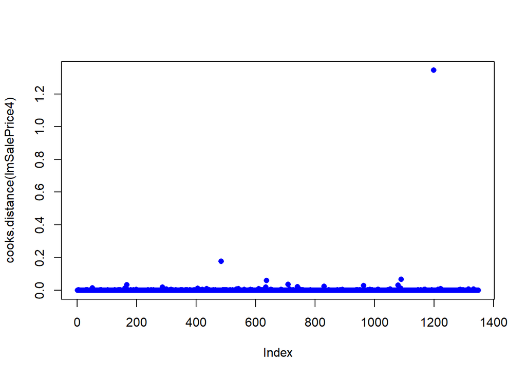

```r
plot(cooks.distance(lmSalePrice4), pch = 16, col = "blue")
```

# Conclusions

Tras analitzar les característiques d’aquest data set sobre les cases de Iowa, s’observa que els valors NA són propis del domini, o almenys així es registra en la definició del data set. S’aprecien valors outliers que impacten la potència estadística, però es decideix no treurel’s donat que semblen valors correctes analitzat el contexte d’altres variables que indiquen que el preu podria estar justificat, per la qualitat dels materials, any de construcció, metres del garatge o altres característiques que fan pensar que el valor és correcte. En aquest sentit hem tingut un dilema en quant a l’eliminació o tractament dels outliers per a obtenir una major potència estadística vs mantenir els valors al comprovar que tot indica que són correctes. Finalment s’ha decidit la segona opció.

Es fa una reducció de la dimensionalitat: eliminant aquells atributs que tenen el valor NA en la majoria dels seus registres i aquells atributs on no s’observa cap correlació amb la variable SalePrice. Per a analitzar la correlació dels atributs categòrics es creen variables numèriques ordinals a partir de les variables qualitatives. En els casos on no es pot establir un ordre es fa una mitja del preu per cadascú de les categories de la variable i s’estableix així l’ordre. Donat que hi ha una manca de normalitat en les variables, s’aplica el test de correlació no paramètric de Spearman.

En quant a la comparació de grups, tant en la comparació del preu per barris com comparant els preus dels anys 80 i 90, s’observen diferencies estadístiques en el preu de venda, més clares en la comparació per barris i no tan evidents en la comparació de preus entre els 80 i els 90 on hi ha un lleuger aument de la mitjana dels preus i una forta presència de preus molt elevats en els anys 90 (outliers).

# WEBGRAPHY

HousePrices - kaggle https://www.kaggle.com/c/house-prices-advanced-regression-techniques/overview

HousePrices - kaggle - Tutorials https://www.kaggle.com/c/house-prices-advanced-regression-techniques/overview/tutorials

HousePrices - Kaggle - Start Here - Visualization and Model Stacking https://www.kaggle.com/rp1611/start-here-visualization-and-model-stacking

Trabajo de Fin de Grado - ESTUDIO DE TÉCNICAS SUPERVISADAS DE REDUCCIÓN DE DIMENSIONALIDAD PARA PROBLEMAS DE CLASIFICACIÓN - Álvaro Soriano Maganto 2016-2017 https://e-archivo.uc3m.es/bitstream/handle/10016/26504/TFG_Alvaro_Soriano_Maganto.pdf

The most common dimension techniques - RPubs https://rpubs.com/Saskia/520216

Análisis de Regresión - Alfonso Novales - Departamente de Economía Cuantitativa 2010 https://www.ucm.es/data/cont/docs/518-2013-11-13-Analisis%20de%20Regresion.pdf

StackOverflow - R - Perform a levene test with two samples with different sizes https://stackoverflow.com/questions/43749166/r-perform-a-levene-test-with-two-samples-with-different-sizes